# Oscar Winner Ages Case Study

Jill E. Thomley

Saturday, October 12, 2019 @ 05:01 PM

```r
library(tidyverse)
library(kableExtra)
library(ggthemes)
```

```r
oscar <- read_csv("https://raw.githubusercontent.com/STAT-JET-ASU/Datasets/master/Instructor/oscarages.csv")
glimpse(oscar)
```

```
Observations: 350
Variables: 6
$ ceremony <dbl> 1929, 1929, 1930, 1930, 1930, 1930, 1931, 1931, 1932, 1…
$ decade   <chr> "1920s-30s", "1920s-30s", "1920s-30s", "1920s-30s", "19…
$ category <chr> "Best Actor", "Best Actress", "Best Actor", "Best Actor…
$ name     <chr> "Emil Jannings", "Janet Gaynor", "Warner Baxter", "Geor…
$ age      <dbl> 44, 22, 41, 62, 37, 30, 53, 62, 35, 47, 32, 34, 26, 34,…
$ title    <chr> NA, NA, "In Old Arizona", "Disraeli", "Coquette", "The …
```

```r
head(oscar)
```

```
# A tibble: 6 x 6
  ceremony decade    category     name            age title
     <dbl> <chr>     <chr>        <chr>         <dbl> <chr>
1     1929 1920s-30s Best Actor   Emil Jannings    44 <NA>
2     1929 1920s-30s Best Actress Janet Gaynor     22 <NA>
3     1930 1920s-30s Best Actor   Warner Baxter    41 In Old Arizona
4     1930 1920s-30s Best Actor   George Arliss    62 Disraeli
5     1930 1920s-30s Best Actress Mary Pickford    37 Coquette
6     1930 1920s-30s Best Actress Norma Shearer    30 The Divorcee
```

In January 2007, Entertainment Weekly magazine featured a cover story about three Academy Award nominees for Best Actress: Meryl Streep, Judy Densch, and Helen Mirren. One primary focus of the article was how old these three women were, relative to previous winners, and the perceived Hollywood bias in favor of younger actresses. This discussion that persists in one form or another to this day. (data: oscarages.csv)

1. Use `read_csv` to import the data, then `glimpse` and `head` to display the dataset structure.
2. Use `filter` and a single `summarize` (with any other necessary functions) to compute and display five-number summaries, IQR, and the lower and upper fences for Best Actor and Best Actress winners prior to 2007.

```r
oscarpre2007 <- oscar %>%
  filter(ceremony < 2007, category %in% c("Best Actor", "Best Actress"))

agesumms <- oscarpre2007 %>%
  group_by(category) %>%
  summarize(minimum = fivenum(age)[1],
            Q1          = fivenum(age)[2],
            median      = fivenum(age)[3],
            Q3          = fivenum(age)[4],
            maximum     = fivenum(age)[5],
            iqr         = IQR(age),
            lowerfence  = Q1 - 1.5*iqr,
            upperfence  = Q3 + 1.5*iqr)

# https://cran.r-project.org/web/packages/kableExtra/vignettes/awesome_table_in_html.html
kable(agesumms, format = "html", escape = FALSE, align = c("l", rep("c", times = 7))) %>%
  kable_styling(bootstrap_options = c("striped", "condensed"))
```

| category | minimum | Q1 | median | Q3 | maximum | iqr | lowerfence | upperfence |
| --- | --- | --- | --- | --- | --- | --- | --- | --- |
| Best Actor | 29 | 37.5 | 42 | 48.5 | 74 | 11 | 21 | 65 |
| Best Actress | 21 | 27.5 | 33 | 38.5 | 81 | 11 | 11 | 55 |

3. Create boxplots to compare the ages of Best Actor and Best Actress winners prior to 2007.

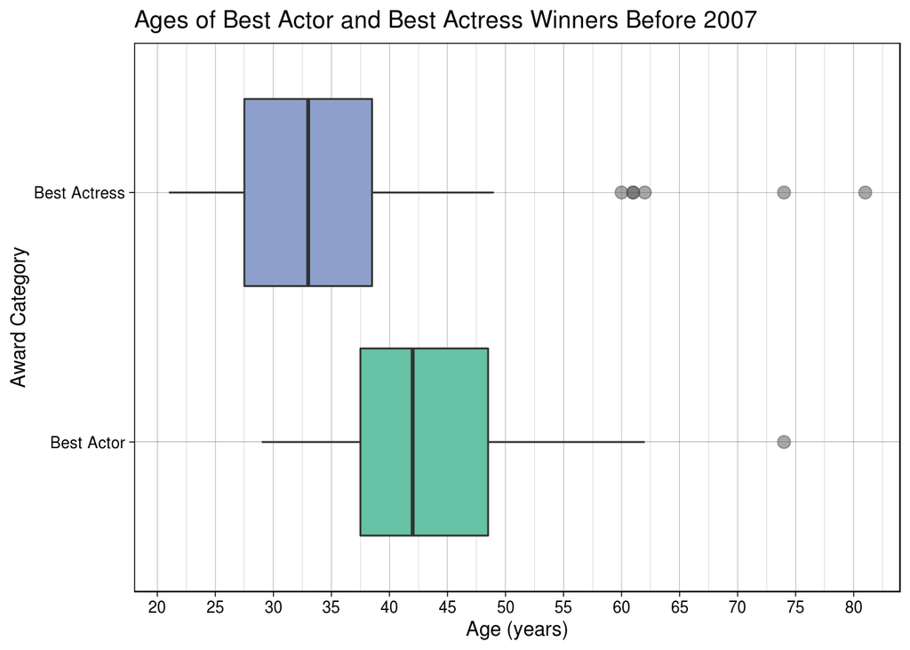

```r
# http://bconnelly.net/posts/creating_colorblind-friendly_figures/
# https://i.stack.imgur.com/eddZp.png
# https://www.color-blindness.com/coblis-color-blindness-simulator/

ggplot(oscarpre2007, aes(x = category, y = age)) +
  geom_boxplot(fill = c("#66C2A5", "#8DA0CB"),
               outlier.colour = "#505050",
               outlier.size = 3,
               outlier.alpha = 0.5) +
  labs(title = "Ages of Best Actor and Best Actress Winners Before 2007",
       x = "Award Category",
       y = "Age (years)") +
  scale_y_continuous(breaks = seq(20, 85, 5)) +
  theme_linedraw() +
  coord_flip()
```

4. Which actress actually won the Best Actress Oscar in 2007? How old was she? For what movie did she win? Use the `filter` and `select` functions to find and display the answer, not visual inspection of the dataset.

```r
actresswinner2007 <- oscar %>%
  filter(ceremony == 2007, category == "Best Actress") %>%
  select(name, age, title)

actresswinner2007
```

```
# A tibble: 1 x 3
  name           age title
  <chr>        <dbl> <chr>
1 Helen Mirren    61 The Queen
```

6. Was the 2007 Best Actress winner an outlier compared to previous Best Actress winners? If she were a man, would she have been an outlier compared to previous Best Actor winners? Determine the answers using code, not visual inspection.

```r
actresswinner2007$age > agesumms$upperfence
```

```
[1] FALSE  TRUE
```

```r
agesumms %>% select(category, upperfence) %>% mutate(IsHelenMirrenOutlier = actresswinner2007$age > upperfence)
```

```
# A tibble: 2 x 3
  category     upperfence IsHelenMirrenOutlier
  <chr>             <dbl> <lgl>
1 Best Actor           65 FALSE
2 Best Actress         55 TRUE
```

7. In what way do your analyses appear to support an assertion of age bias againt women in Hollywood? Cite values of specific statistics and/or features of your boxplots in your discussion.

```r
# not required, but these are the cases that are outliers

oscarpre2007 %>% filter((category == "Best Actress" & age > 55) |
                        (category == "Best Actor" & age > 65))
```

```
# A tibble: 7 x 6
  ceremony decade    category    name             age title
     <dbl> <chr>     <chr>       <chr>          <dbl> <chr>
1     1931 1920s-30s Best Actre… Marie Dressler    62 Min and Bill
2     1968 1960s     Best Actre… Katharine Hep…    60 Guess Who's Coming t…
3     1969 1960s     Best Actre… Katharine Hep…    61 Funny Girl
4     1982 1980s     Best Actor  Henry Fonda       74 On Golden Pond
5     1982 1980s     Best Actre… Katharine Hep…    74 On Golden Pond
6     1986 1980s     Best Actre… Geraldine Page    61 The Trip to Bountiful
7     1990 1990s     Best Actre… Jessica Tandy     81 Driving Miss Daisy
```

### **Problem 6**

NOTE: You do not need to label your plots here. If you store a calculated answer, be sure to print it as well.

1. Go to the Galton height data [description](https://stat-jet-asu.github.io/Datasets/InstructorDescriptions/galtonheightdata.html) and import the dataset. Use `glimpse` and `head` to display the dataset structure.

```r
galton <- read_csv(file = url("https://raw.githubusercontent.com/STAT-JET-ASU/Datasets/master/Instructor/galtonheightdata.csv"))
glimpse(galton)
```

```
Observations: 898
Variables: 6
$ Family <chr> "1", "1", "1", "1", "2", "2", "2", "2", "3", "3", "4", "4…
$ Father <dbl> 78.5, 78.5, 78.5, 78.5, 75.5, 75.5, 75.5, 75.5, 75.0, 75.…
$ Mother <dbl> 67.0, 67.0, 67.0, 67.0, 66.5, 66.5, 66.5, 66.5, 64.0, 64.…
$ Gender <chr> "M", "F", "F", "F", "M", "M", "F", "F", "M", "F", "M", "M…
$ Height <dbl> 73.2, 69.2, 69.0, 69.0, 73.5, 72.5, 65.5, 65.5, 71.0, 68.…
$ Kids   <dbl> 4, 4, 4, 4, 4, 4, 4, 4, 2, 2, 5, 5, 5, 5, 5, 6, 6, 6, 6, …
```

```r
head(galton)
```

```
# A tibble: 6 x 6
  Family Father Mother Gender Height  Kids
  <chr>   <dbl>  <dbl> <chr>   <dbl> <dbl>
1 1        78.5   67   M        73.2     4
2 1        78.5   67   F        69.2     4
3 1        78.5   67   F        69       4
4 1        78.5   67   F        69       4
5 2        75.5   66.5 M        73.5     4
6 2        75.5   66.5 M        72.5     4
```

2. Use `mutate` and `ifelse` or `case_when` to recode two variables: (1) `Gender` to “male” and female“; and (2) `Height` so that all the female heights are multiplied by 1.08 while male heights stay the same.

```r
# select used after the mutate is optional, done here for visualization
galton <- galton %>%
  mutate(GenderR = case_when(Gender == "M" ~ "male",
                             Gender == "F" ~ "female"),
         HeightR = case_when(GenderR == "male" ~ Height,
                             GenderR == "female" ~ Height * 1.08)) %>%
  select(Family, Father, Mother, Gender, GenderR, Height, HeightR, Kids)
head(galton)
```

```
# A tibble: 6 x 8
  Family Father Mother Gender GenderR Height HeightR  Kids
  <chr>   <dbl>  <dbl> <chr>  <chr>    <dbl>   <dbl> <dbl>
1 1        78.5   67   M      male      73.2    73.2     4
2 1        78.5   67   F      female    69.2    74.7     4
3 1        78.5   67   F      female    69      74.5     4
4 1        78.5   67   F      female    69      74.5     4
5 2        75.5   66.5 M      male      73.5    73.5     4
6 2        75.5   66.5 M      male      72.5    72.5     4
```

3. Assess recoded height for normality using a density plot, ECDF plot, QQ plot, skewness and kurtosis. All plots should have a theoretical reference line for comparison. State your conclusion and how you made your decision.

```r
ht_stats <- galton %>%
  summarize(xbar = mean(HeightR), stdv = sd(HeightR))
ht_stats
```

```
# A tibble: 1 x 2
   xbar  stdv
  <dbl> <dbl>
1  69.2  2.60
```

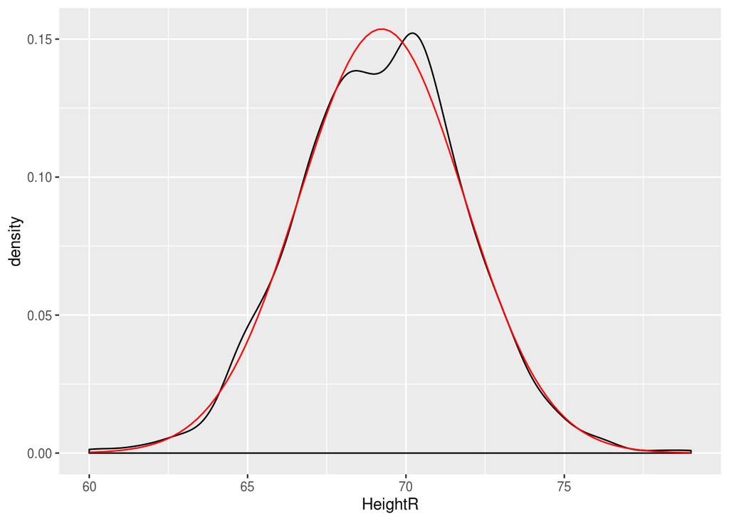

```r
ggplot(galton, aes(x = HeightR)) +
  geom_density() +
  stat_function(fun = dnorm,
                args = list(ht_stats$xbar, ht_stats$stdv),
                color = "red")
```

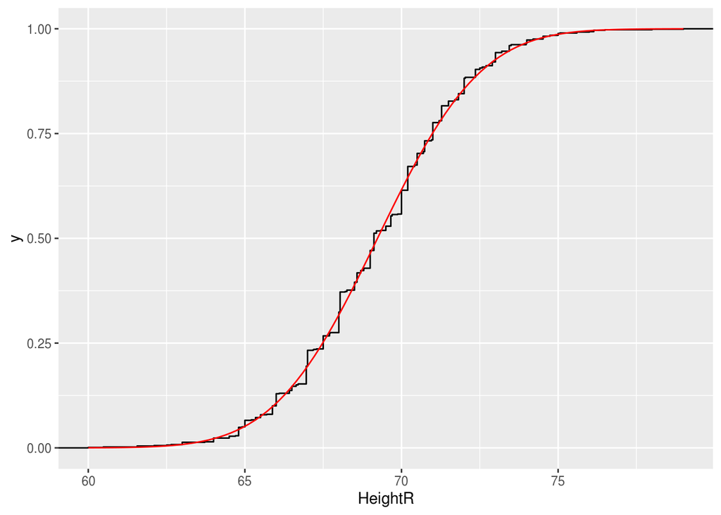

```r
ggplot(galton, aes(x = HeightR)) +
  stat_ecdf() +
  stat_function(fun = pnorm,
                args = list(ht_stats$xbar, ht_stats$stdv),
                color = "red")
```

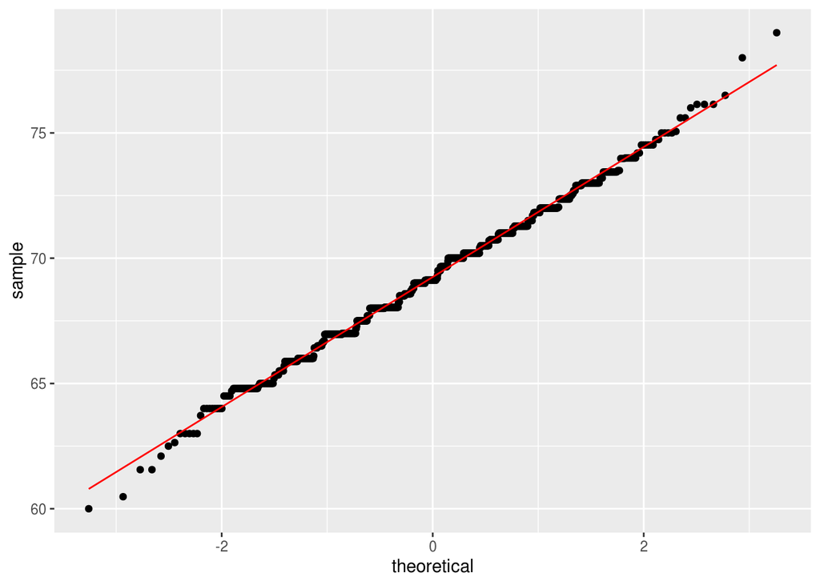

```r
ggplot(galton, aes(sample = HeightR)) +
  stat_qq() +
  stat_qq_line(color = "red")
```

```r
library(moments)
skewK <- tibble(statistic = c("Skewness", "Kurtosis", "Excess K"),
                theory = c(0, 3, 0),
                data   = round(c(skewness(galton$HeightR),
                                 kurtosis(galton$HeightR),
                                 kurtosis(galton$HeightR) - 3),
                               2))
print.data.frame(skewK, row.names = FALSE)
```

```
 statistic theory  data
  Skewness      0 -0.02
  Kurtosis      3  3.26
  Excess K      0  0.26
```

**ANSWER**: The density plot shows that the data distribution is roughly symmetric and bell-shaped, with the primary deviation from normality being a slightly off-center peak. This is supported by a skewness value that is very near zero and a kurtosis that is a only a little larger than the normal distribution’s theoretical value of 3. The ECDF plot does not vary too far from the normal distribution CDF, and the QQ plot is a quite linear with no systematic deviation from the normal reference line. It is fair to say these data are approximately normally distributed, with deviations being explained by sampling variability.

**Names of Collaborators**: Me, Myself, and I :)